# Diseño y Evaluación de RCTs

Marisol Nava León 125149

Daniela Brito Calderon 198067

Coral Hernández Reyes 191896

Gaspar Samuel Salazar Salgado 191917

03 mayo 2021

```r
library(tidyverse)
library(data.table)
library(broom)
library(knitr)
library(lubridate)
library(RCT)
library(kableExtra)
library(stargazer)
```

## Contexto

Rappi te contrata para hacer una intervención que active a sus usuarios en la plataforma. La empresa quiere evaluar si es necesario darles cash los usuarios (y cuánto) para reactivar a los usuarios o si es suficiente con una campaña informativa.

Para ello, te decides a realizar un experimento factorial donde evaluas:

- El impacto de mandar un mensaje informativo donde muestres las nuevas tiendas afiliadas a Rappi, y
- El impacto de dar 100 ó 200 pesos en cupones

Finalmente, les gustaría entender cómo interactuar el mostras las nuevas tiendas aunado con dar dinero en cupones.

A la empresa le gustaría entender el impacto de la intervención sobre:

- Las compras
- La tasa de usuarios activos en la app (transaccionar: abrir app o hacer compras)

## Datos

Los datos para asignar los pueden encontrar en `universo.Rdata`.

Cargemos los datos

```r
setwd("C:/Users/Samuelk/Documents/ITAM/Econo Comp/Tarea 3")
load('universo.Rdata')
```

### 1. Cuántos grupos de tratamiento debe de haber? Elabora sobre que intervención va a recibir cada uno

- Control: Ninguna intervención
- Trat 1: Sólo mensaje
- Treat 2: Sólo cupón $100
- Treat 3: Sólo cupón de $200
- Treat 4: Sólo cupón de $300
- Treat 5: Mensaje + $100
- Treat 6: Mensaje + $200
- Treat 7: Mensaje + $300

### 2 (2pts). Como pueden notar, tenemos 2 poblaciones: Usuarios inactivos y usuarios que nunca estuvieron activos. Para ellos, las tasas de transaccionalidad son hasta ahora 7.94% y 0%. Utiliza esta información para hacer pruebas de poder: Dada esta tasa y población, cuál es el efecto mínimo detectable sobre la tasa de transaccionalidad como función de cuantas observaciones asignamos al grupo control? Interpreta. (Tip: asegurate de dejar claros los grupos comparados en esta prueba)

```r
# Convertimos la variable population a factor para conocer el tamaño de cada grupo (Inactive, Never Active)
universo$population<-factor(universo$population)
summary(universo$population)
```

```
    Inactive Never Active
       14084        90107
```

```r
# Se obtienen 14084 individuos inactive y 90107 inactive, con lo cual se puede estimar la tasa de transaccionalidad, a partir de las tasas que conocemos para cada grupo (7.94 y 0)
p_y<-0.0794*(14084/194191)+0*(90107/194191)
tau2<-tau_min_probability(p_y,N=nrow(universo),share_control = seq(0,1,0.05),n_groups=8)
stargazer(tau2,type="text",summary=FALSE,font.size="tiny")
```

```
================================================================================================================
   share_control share_ti share_treat    N    N_control   N_treat      N_ti    tau_min_global tau_min_each_treat
----------------------------------------------------------------------------------------------------------------
1        0        0.143        1      104,191     0       104,191   14,884.430      Inf
2      0.050      0.136      0.950    104,191 5,209.550  98,981.450 14,140.210     0.003            0.003
3      0.100      0.129      0.900    104,191 10,419.100 93,771.900 13,395.990     0.002            0.003
4      0.150      0.121      0.850    104,191 15,628.650 88,562.350 12,651.760     0.002            0.003
5      0.200      0.114      0.800    104,191 20,838.200 83,352.800 11,907.540     0.002            0.002
6      0.250      0.107      0.750    104,191 26,047.750 78,143.250 11,163.320     0.002            0.002
7      0.300      0.100      0.700    104,191 31,257.300 72,933.700 10,419.100     0.001            0.002
8      0.350      0.093      0.650    104,191 36,466.850 67,724.150 9,674.879      0.001            0.002
9      0.400      0.086      0.600    104,191 41,676.400 62,514.600 8,930.657      0.001            0.002
10     0.450      0.079      0.550    104,191 46,885.950 57,305.050 8,186.436      0.001            0.003
11     0.500      0.071      0.500    104,191 52,095.500 52,095.500 7,442.214      0.001            0.003
12     0.550      0.064      0.450    104,191 57,305.050 46,885.950 6,697.993      0.001            0.003
13     0.600      0.057      0.400    104,191 62,514.600 41,676.400 5,953.771      0.001            0.003
14     0.650      0.050      0.350    104,191 67,724.150 36,466.850 5,209.550      0.001            0.003
15     0.700      0.043      0.300    104,191 72,933.700 31,257.300 4,465.329      0.001            0.003
16     0.750      0.036      0.250    104,191 78,143.250 26,047.750 3,721.107      0.002            0.004
17     0.800      0.029      0.200    104,191 83,352.800 20,838.200 2,976.886      0.002            0.004
18     0.850      0.021      0.150    104,191 88,562.350 15,628.650 2,232.664      0.002            0.005
19     0.900      0.014      0.100    104,191 93,771.900 10,419.100 1,488.443      0.002            0.006
20     0.950      0.007      0.050    104,191 98,981.450 5,209.550   744.221       0.003            0.008
21       1          0          0      104,191  104,191       0          0           Inf
----------------------------------------------------------------------------------------------------------------
```

### 3. Repite el mismo ejercicio pero ahora para usando las compras totales como variable objetivo. Elige un share de control con base en tu respuesta de esta y la anterior pregunta

```r
tau3<-tau_min(universo$total_purchases,N=nrow(universo),share_control = seq(0,1,0.05),n_groups=8)
stargazer(tau3,type="text",summary=FALSE, font.size="tiny")
```

```
================================================================================================================
   share_control share_ti share_treat    N    N_control   N_treat      N_ti    tau_min_global tau_min_each_treat
----------------------------------------------------------------------------------------------------------------
1        0        0.143        1      104,191     0       104,191   14,884.430      Inf
2      0.050      0.136      0.950    104,191 5,209.550  98,981.450 14,140.210     23.081           26.316
3      0.100      0.129      0.900    104,191 10,419.100 93,771.900 13,395.990     16.768           21.210
4      0.150      0.121      0.850    104,191 15,628.650 88,562.350 12,651.760     14.088           19.419
5      0.200      0.114      0.800    104,191 20,838.200 83,352.800 11,907.540     12.576           18.653
6      0.250      0.107      0.750    104,191 26,047.750 78,143.250 11,163.320     11.617           18.368
7      0.300      0.100      0.700    104,191 31,257.300 72,933.700 10,419.100     10.977           18.368
8      0.350      0.093      0.650    104,191 36,466.850 67,724.150 9,674.879      10.546           18.569
9      0.400      0.086      0.600    104,191 41,676.400 62,514.600 8,930.657      10.268           18.933
10     0.450      0.079      0.550    104,191 46,885.950 57,305.050 8,186.436      10.111           19.450
11     0.500      0.071      0.500    104,191 52,095.500 52,095.500 7,442.214      10.061           20.121
12     0.550      0.064      0.450    104,191 57,305.050 46,885.950 6,697.993      10.111           20.967
13     0.600      0.057      0.400    104,191 62,514.600 41,676.400 5,953.771      10.268           22.023
14     0.650      0.050      0.350    104,191 67,724.150 36,466.850 5,209.550      10.546           23.346
15     0.700      0.043      0.300    104,191 72,933.700 31,257.300 4,465.329      10.977           25.032
16     0.750      0.036      0.250    104,191 78,143.250 26,047.750 3,721.107      11.617           27.244
17     0.800      0.029      0.200    104,191 83,352.800 20,838.200 2,976.886      12.576           30.287
18     0.850      0.021      0.150    104,191 88,562.350 15,628.650 2,232.664      14.088           34.794
19     0.900      0.014      0.100    104,191 93,771.900 10,419.100 1,488.443      16.768           42.419
20     0.950      0.007      0.050    104,191 98,981.450 5,209.550   744.221       23.081           59.743
21       1          0          0      104,191  104,191       0          0           Inf
----------------------------------------------------------------------------------------------------------------
```

### 4 (2ptos) Qué variables crees que puedan estar más correlacionadas con el impacto? Justifica tu respuesta y elige un set

Edad, género y tipo de población podrían estar más correlacionadas con el impacto de tratamiento. En particular, las personas de distinta edad podrían reaccionar distinto al hecho de recibir el mensaje o recibir cupones; por ejemplo, a los más jóvenes podría darles flojera leer sobre las nuevas tiendas afiliadas pero podrían reaccionar mejor al recibir cupones (ya que podrían tener un presupuesto más limitado para gastar a través de la app, que las personas de mayor edad). También hombres y mujeres podrían reaccionar diferente a recibir el mensaje pues podría ser que alguno de ellos, por ejemplo, las mujeres, se encarguen más frecuentemente de realizar las compras, por lo que están más familiarizadas con las tiendas disponibles en la app y reaccionen mejor ante el conocimiento de nuevas tiendas que se agregan.  
Por otra parte, el tipo de población de que se trate (never active o unactive) también puede estar muy relacionado con el impacto, pues se esperaría que haya un mayor impacto para aquellos que han estado activos alguna vez vs los que nunca han estado activos, quienes tendrían una “barrera” de uso mayor.

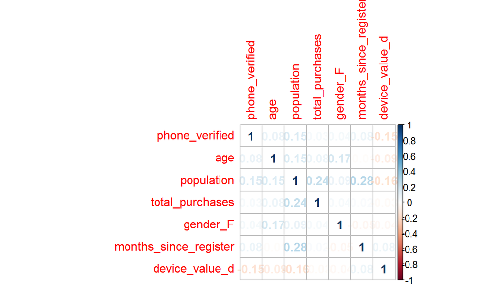

```r
#Volvemos las variables categoricas a numéricas para poder correr el colerrograma
datos_num<-universo%>%select(-user_id)

datos_num$population<-as.factor(datos_num$population)
datos_num$population<-ifelse(datos_num$population=="Inactive",1,0)


datos_num$device_value_d <-ifelse(datos_num$device_value== "[$0-$10,000]" , 1,
                  ifelse(datos_num$device_value== "[$10,001+]", 2,
                  ifelse(datos_num$device_value== "No info", 3,0)))

# Transformo mis variables a numéricas para el correlograma
library(corrplot)

a<-cor(datos_num  %>% select(-device_value))

corrplot(a, method="number")
```

### 5 (2ptos) Realiza la asignación aleatoria. Muestra la distribución de los grupos por estrato, los misfits. Sin mirar el balance, lograron una asignación aleatoria exitosa? Justifica tu respuesta

```r
# Convertimos age en cuartiles
universo$agelabel<-ntile_label(universo$age,n=4)
# Realizamos la asignación
assignment<-treatment_assign(data = universo, share_control = 0.3, n_t = 7, strata_varlist =dplyr::vars(agelabel, gender_F, population), missfits="NA", seed = 1990, key = "user_id")
tabla<-as.data.frame(assignment$summary_strata)
stargazer(tabla,type="text",summary=FALSE)
```

```
=============================================================
   strata agelabel  gender_F  population  n_strata n_missfits
-------------------------------------------------------------
1    1    [18 a 20]    0       Inactive     568        8
2    2    [18 a 20]    0     Never Active  21,446      6
3    3    [18 a 20]    1       Inactive     148        8
4    4    [18 a 20]    1     Never Active  3,886       6
5    5    [20 a 26]    0       Inactive    2,644       4
6    6    [20 a 26]    0     Never Active  17,658      8
7    7    [20 a 26]    1       Inactive    1,007       7
8    8    [20 a 26]    1     Never Active  4,739       9
9    9    [26 a 34]    0       Inactive    2,744       4
10   10   [26 a 34]    0     Never Active  16,248      8
11   11   [26 a 34]    1       Inactive    1,325       5
12   12   [26 a 34]    1     Never Active  5,731       1
13   13   [34 a 84]    0       Inactive    3,252       2
14   14   [34 a 84]    0     Never Active  13,472      2
15   15   [34 a 84]    1       Inactive    2,396       6
16   16   [34 a 84]    1     Never Active  6,927       7
-------------------------------------------------------------
```

Sin mirar el balance no podemos saber si se trató de una asignación aleatoria exitosa porque no podemos evaluar unconfoundness/excludability, pero al menos sabemos que hay balance en términos de las variables por las que estratificamos.

### 7. Realiza las pruebas de balance t sobre todas las variables (Tip: transforma las categóricas en dummys). Parece haber balance?

```r
load("universo.Rdata")

# Las pruebas se realizan sobre todas las variables observables
# Creamos dummies
library(fastDummies)
universo_dum<-dummy_cols(universo,select_columns = c("device_value", "phone_verified","population","gender_F"),remove_first_dummy = FALSE,remove_selected_columns = TRUE)

# Agregamos variable de asignación al tratamiento
base<-as.data.frame(assignment$data)

universo_dum<-merge(universo_dum,base, by="user_id")

#Eliminamos user_id, strata, missfit y na's
universo_dum<-universo_dum[,-1]
universo_dum<-universo_dum[,-13]
universo_dum<-universo_dum[,-14]
universo_dum<-universo_dum[!is.na(universo_dum$treat),]

tabla_b<-balance_table(universo_dum,"treat")

kbl(tabla_b, booktabs = T, caption = "<center><strong>Aleatoriedad del instrumento</strong></center>",
    digits = c(3,3,3,3,3)) %>%
  kable_classic_2(full_width = F, html_font = "Cambria", fixed_thead = T)
```

**Aleatoriedad del instrumento**

| variables1 | Media_control1 | Media_trat1 | Media_trat2 | Media_trat3 | Media_trat4 | Media_trat5 | Media_trat6 | Media_trat7 | p_value1 | p_value2 | p_value3 | p_value4 | p_value5 | p_value6 | p_value7 |
| --- | --- | --- | --- | --- | --- | --- | --- | --- | --- | --- | --- | --- | --- | --- | --- |
| age | 29.071 | 29.104 | 29.094 | 29.090 | 29.114 | 29.055 | 29.187 | 29.185 | 0.793 | 0.859 | 0.881 | 0.735 | 0.893 | 0.362 | 0.370 |
| device_value_[$0-$10,000] | 0.475 | 0.477 | 0.487 | 0.483 | 0.464 | 0.465 | 0.484 | 0.481 | 0.817 | 0.043 | 0.154 | 0.050 | 0.070 | 0.110 | 0.277 |
| device_value_[$10,001+] | 0.001 | 0.001 | 0.001 | 0.001 | 0.000 | 0.001 | 0.001 | 0.001 | 0.339 | 0.915 | 0.913 | 0.109 | 0.484 | 0.913 | 0.104 |
| device_value_No info | 0.524 | 0.523 | 0.513 | 0.516 | 0.536 | 0.534 | 0.515 | 0.517 | 0.773 | 0.042 | 0.152 | 0.044 | 0.076 | 0.109 | 0.232 |
| gender_F_0 | 0.749 | 0.750 | 0.749 | 0.749 | 0.749 | 0.750 | 0.749 | 0.749 | 0.938 | 0.938 | 1.000 | 1.000 | 0.938 | 1.000 | 1.000 |
| gender_F_1 | 0.251 | 0.250 | 0.251 | 0.251 | 0.251 | 0.250 | 0.251 | 0.251 | 0.938 | 0.938 | 1.000 | 1.000 | 0.938 | 1.000 | 1.000 |
| months_since_register | 4.854 | 4.838 | 4.794 | 4.838 | 4.894 | 4.880 | 4.767 | 4.827 | 0.743 | 0.200 | 0.726 | 0.424 | 0.594 | 0.056 | 0.570 |
| phone_verified_0 | 0.583 | 0.584 | 0.575 | 0.576 | 0.586 | 0.578 | 0.579 | 0.578 | 0.918 | 0.156 | 0.167 | 0.671 | 0.318 | 0.406 | 0.324 |
| phone_verified_1 | 0.417 | 0.416 | 0.425 | 0.424 | 0.414 | 0.422 | 0.421 | 0.422 | 0.918 | 0.156 | 0.167 | 0.671 | 0.318 | 0.406 | 0.324 |
| population_Inactive | 0.135 | 0.134 | 0.135 | 0.135 | 0.135 | 0.134 | 0.135 | 0.135 | 0.884 | 0.885 | 1.000 | 1.000 | 0.884 | 1.000 | 1.000 |
| population_Never Active | 0.865 | 0.866 | 0.865 | 0.865 | 0.865 | 0.866 | 0.865 | 0.865 | 0.884 | 0.885 | 1.000 | 1.000 | 0.884 | 1.000 | 1.000 |
| total_purchases | 57.724 | 55.997 | 50.655 | 47.819 | 46.031 | 51.913 | 58.425 | 61.601 | 0.787 | 0.248 | 0.092 | 0.043 | 0.381 | 0.920 | 0.587 |

En general parece haber balance, pues con un 5% de significancia, solo hay 5 de 84 pruebas t que se rechazan. Sin embargo, hay 2 variables (device_value_[0-10,000] y device_value_No info) que concentran 4 de esas pruebas, por lo que podrían estar desbalanceadas. En la evaluación de este experimento, se podrían incluir dichas variables, para asegurarnos de recuperar el balance.

### 8. Repite el ejercicio pero ahora con pruebas de balance conjuntas. Muestra los resultados (incluyendo el estadístico de prueba, grados de libertad y p values) Interpreta

```r
balance_r<-balance_regression(universo_dum,"treat")
efe<-balance_r$F_test
stargazer(as.data.frame(efe),type="text",summary=FALSE, font.size = "small")
```

```
===============================================================
  estadistico  Msj1    Msj2   Msj3   Msj4   Msj5   Msj6   Msj7
---------------------------------------------------------------
1 F-statistic  0.179  0.991  0.690  1.142  0.761  0.834  0.850
2      k         8      8      8      8      8      8      8
3    n-k-1    41,615  41,647 41,631 41,631 41,615 41,631 41,631
4 F_critical   0.342  0.342  0.342  0.342  0.342  0.342  0.342
5   p_value    0.994  0.440  0.701  0.331  0.637  0.572  0.558
6 R cuadrada  0.00003 0.0002 0.0001 0.0002 0.0001 0.0002 0.0002
---------------------------------------------------------------
```

Todos los valores p son suficientemente grandes, por lo que en ninguno de los grupos se rechaza la hipótesis de que las covariables no explican la Pr de pertenecer al tratamiento, lo cual nos da evidencia de que la asignación es aleatoria.

### 9. Elabora porqué parecen cumplirse los 3 supuestos de la asignación

```r
datos<-as.data.frame(assignment$data)
table(datos$treat, useNA = "ifany")
```

```
    0     1     2     3     4     5     6     7  <NA>
31230 10394 10426 10410 10410 10394 10410 10410   107
```

```r
prop.table(table(datos$treat, useNA = "ifany"))
```

```
         0          1          2          3          4          5          6
0.29973798 0.09975910 0.10006622 0.09991266 0.09991266 0.09975910 0.09991266
         7       <NA>
0.09991266 0.00102696
```

Parece que se cumplen los tres supuestos, ya que:

- SUTVA: Estamos asignando tratamientos a nivel individual (mensajes a sus dispositivos privados y dinero que pueden utilizar en su cuenta); no se está considerando realizar algún otro esfuerzo de publicidad, por ejemplo, en medios masivos, lo que evita que el grupo de control se entere de la información que se les dio a los individuos tratados o que los grupos de control se enteren del dinero que se les ofreció a otros grupos (lo que podría hacerles cambiar su comportamiento). Por lo tanto, no parece hacer fuentes de contaminación que impidan que se cumpla este supuesto.
- Overlap: Podemos observar que las probabilidades de cada individuo de pertenecer a algún grupo de tratamiento están entre 0 y 1 (sin incluirlos).
- Unconfoundness: Las pruebas de balance anteriores, en particular, la prueba de balance conjunta, dan evidencia de que los grupos se encuentran balanceados, por lo que parece que la aleatorización funcionó y que no existe relación entre la asignación de tratamiento y las características (observables) de los individuos.

### 10. Elabora un pitch de negocio sobre los beneficios que este experimento podría dejar a Rappi.

Si realizamos el experimento propuesto, podríamos conocer qué incentivos son mejores para que los clientes se activen en la plataforma, de tal manera que se utilice la estrategia menos costosa. Además, obtendríamos información de cómo focalizar los incentivos, para obtener la respuesta más alta posible haciendo un uso óptimo de los recursos disponibles. Con esto, se podría generar una estrategia que permita a Rappi una mayor activación de sus usuarios y establecerse como una opción clara cuando se hable de compras a través de apps.

## Evaluación

Pasemos a la evaluación de tu intervención. En este ejercicio, Rappi diseño un nuevo experimento con tus enseñanzas algo distinto al tuyo.

Este consistió en 6 grupos de tratamiento y un control:

- T1: Dar 100 pesos en cupones (con mensaje)
- T2: Dar 200 pesos en cupones (con mensaje)
- T3: Dar un descuento de 20% en la siguiente compra
- T4: Dar un descuento de 25% en la siguiente compra
- T5: Ofrecer 2% de descuento en la siguiente compra por cada usuario que refieran
- T6: Ofrecer 4% de descuento en la siguiente compra por cada usuario que refieran

Te piden ahora medir este experimento (estratificado por `phone_verified`, `population` y `device_value`) en la base `base_evaluacion.Rdata`. Las variables endogenas son `total_purchases_after` que refleja el gasto total post-tratamiento y `transacted` que refleja abrir la app o hacer compras.

Carguemos la base

```r
rm(list = ls())

load('base_evaluacion.Rdata')
```

### 10 (2ptos). Muestra el estimador ITT para la tasa de transaccionalidad. Recuerda que tu cliente es un grupo empresarial. Por ende, muestra una gráfica donde se aprecie la diferencia entre los grupos de tratamiento y las significancias de manera sencilla. Interpreta tus resultados

```r
#Elaboremos una tabla de balance para revisar nuestro supuesto de unconfoundness y revisar si tendríamos que aumentar alguna variable para volver más eficiente nuestra regresión:
#no se consideras las variables que ya utilizamos para estratificar
universo_f_d<-universo_f%>%select(-user_id,-treat2,-total_purchases_after,-device_value,-missfit,-transacted,-age_median,-strata)

#Volvemos factores algunas variables:
universo_f_d<-dummy_cols(universo_f_d,select_columns = c( "phone_verified","population","gender_F"),remove_first_dummy = FALSE,remove_selected_columns = TRUE)


tabla_c<-balance_table(universo_f_d,"treat")
library(kableExtra)
library(knitr)
tabla_c %>%
  kbl(booktabs = T,
      caption = "Tabla 1: Aleatoriedad del instrumento") %>%
  kable_material(c("striped", "hover"))
```

Tabla 1: Aleatoriedad del instrumento

| variables1 | Media_control1 | Media_trat1 | Media_trat2 | Media_trat3 | Media_trat4 | Media_trat5 | Media_trat6 | p_value1 | p_value2 | p_value3 | p_value4 | p_value5 | p_value6 |
| --- | --- | --- | --- | --- | --- | --- | --- | --- | --- | --- | --- | --- | --- |
| age | 29.0911071 | 30.7567568 | 31.4054054 | 29.9729730 | 33.5810811 | 32.5135135 | 32.6933333 | 0.1738349 | 0.1156760 | 0.4882826 | 0.0032528 | 0.0160296 | 0.0285994 |
| gender_F_0 | 0.7490795 | 0.7027027 | 0.7297297 | 0.6891892 | 0.7297297 | 0.7297297 | 0.7066667 | 0.3889704 | 0.7108623 | 0.2726697 | 0.7108623 | 0.7108623 | 0.4256375 |
| gender_F_1 | 0.2509205 | 0.2972973 | 0.2702703 | 0.3108108 | 0.2702703 | 0.2702703 | 0.2933333 | 0.3889704 | 0.7108623 | 0.2726697 | 0.7108623 | 0.7108623 | 0.4256375 |
| months_since_register | 4.8361479 | 5.1216216 | 6.4729730 | 6.7027027 | 6.0000000 | 5.9729730 | 5.6533333 | 0.5839323 | 0.0450756 | 0.0548914 | 0.1433102 | 0.1858920 | 0.2674021 |
| phone_verified_0 | 0.5806874 | 0.5135135 | 0.5000000 | 0.5000000 | 0.5000000 | 0.5000000 | 0.5066667 | 0.2547548 | 0.1723100 | 0.1723100 | 0.1723100 | 0.1723100 | 0.2069364 |
| phone_verified_1 | 0.4193126 | 0.4864865 | 0.5000000 | 0.5000000 | 0.5000000 | 0.5000000 | 0.4933333 | 0.2547548 | 0.1723100 | 0.1723100 | 0.1723100 | 0.1723100 | 0.2069364 |
| population_Inactive | 0.1336726 | 0.4864865 | 0.4864865 | 0.4864865 | 0.4864865 | 0.4864865 | 0.4800000 | 0.0000001 | 0.0000001 | 0.0000001 | 0.0000001 | 0.0000001 | 0.0000001 |
| population_Never Active | 0.8663274 | 0.5135135 | 0.5135135 | 0.5135135 | 0.5135135 | 0.5135135 | 0.5200000 | 0.0000001 | 0.0000001 | 0.0000001 | 0.0000001 | 0.0000001 | 0.0000001 |
| total_purchases | 54.1078155 | 88.1397160 | 96.7027340 | 348.3584812 | 267.0129541 | 242.8291841 | 89.3180741 | 0.2152909 | 0.1077108 | 0.1436914 | 0.0241803 | 0.0621317 | 0.2933522 |

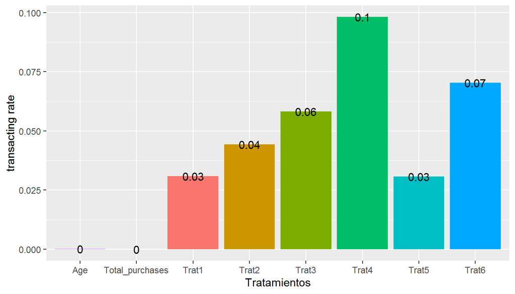

```r
universo_f$phone_verified<-factor(universo_f$phone_verified)
#como se estratificó por las variables phone_verified, population y device_value incluimos los efectos fijos:

eval10<-impact_eval(data = universo_f,
                       endogenous_vars = c("transacted"),
                       treatment = "treat",
                       heterogenous_vars = c("phone_verified","population","device_value"),
                       fixed_effect_vars = c("phone_verified","population","device_value"),
                       control_vars = c("age","total_purchases"))

eval10<-as.data.frame(eval10$transacted)
View(eval10)
eval10$nombre<-c("Trat1","Trat2","Trat3","Trat4","Trat5","Trat6","Age","Total_purchases")


ggplot2::ggplot(data=eval10,aes(x=nombre, y=estimate, fill=rownames(eval10)))+geom_bar(stat="identity")+guides(fill=FALSE)+labs(x="Tratamientos", y="transacting rate")+geom_text(aes(label=round(estimate,digits=2)))
```

### 11. Repite el ejercicio sobre compras totales. Que resultados se aprecian? Que indica esto sobre la rentabilidad del sistema de incentivos?

```r
#como se estratificó por las variables phone_verified, population y device_value incluimos los efectos fijos:

eval11<-impact_eval(data = universo_f,
                       endogenous_vars = c("total_purchases_after"),
                       treatment = "treat",
                       heterogenous_vars = c("phone_verified","population","device_value"),
                       fixed_effect_vars = c("phone_verified","population","device_value"),
                       control_vars = c("age","total_purchases"))
```

```
Error in chol.default(mat[ok, ok]) : 'a' debe tener dimension > 0
```

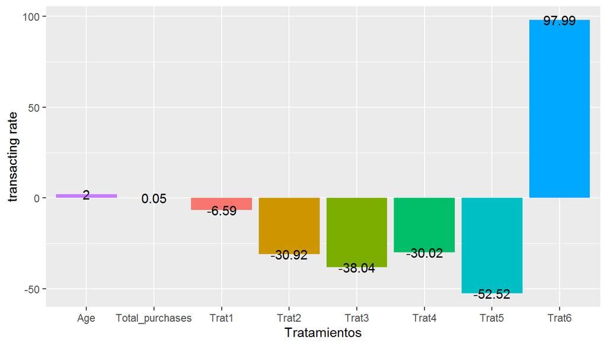

```r
eval11<-as.data.frame(eval11$total_purchases_after)
View(eval11)
eval11$nombre<-c("Trat1","Trat2","Trat3","Trat4","Trat5","Trat6","Age","Total_purchases")


ggplot2::ggplot(data=eval11,aes(x=nombre, y=estimate, fill=rownames(eval11)))+geom_bar(stat="identity")+guides(fill=FALSE)+labs(x="Tratamientos", y="transacting rate")+geom_text(aes(label=round(estimate,digits=2)))
```

Cuando se repite el ejercicio pero esta vez con el gasto total post-tratamiento podemos notar que solo el tratamiento 6 (Ofrecer 4% de descuento en la siguiente compra por cada usuario que refieran) reporta un impacto postivo, en comparación a los otros grupos de tratamiento. Sin embargo ninguna de estas estimaciones es estadísticamente significativa.

### 12. Interpreta el impacto del grupo de referidos 4%. Porque el estimador es tan diferente y a la vez es no significativo? Por que esto no paso en la tasa de transaccionalidad?

Esto sucedió debido a la variación tan grande que existe entre los distintos gastos en los diversos estímulos a los usuarios, de igual forma esta variación afecto la significancia.

### 13 (2ptos). Repite la medición en 11 pero ahora con `log(total_purchases_after+1)`. Que encuentras ahora? Interpreta las diferencias

```r
universo_f$logtotal_p<-log(universo_f$total_purchases_after+1)

eval13<-impact_eval(data = universo_f,
                       endogenous_vars = c("logtotal_p"),
                       treatment = "treat",
                       heterogenous_vars = c("phone_verified","population","device_value"),
                       fixed_effect_vars = c("phone_verified","population","device_value"),
                       control_vars = c("age","total_purchases"))
```

```
Error in chol.default(mat[ok, ok]) : 'a' debe tener dimension > 0
```

```r
(eval13)
```

```
$logtotal_p
# A tibble: 8 x 5
  term               estimate  std.error statistic  p.value
  <chr>                 <dbl>      <dbl>     <dbl>    <dbl>
1 factor(treat)1   0.0282     0.0643         0.439 6.61e- 1
2 factor(treat)2   0.0145     0.0643         0.225 8.22e- 1
3 factor(treat)3   0.0853     0.0643         1.33  1.84e- 1
4 factor(treat)4   0.0196     0.0643         0.306 7.60e- 1
5 factor(treat)5  -0.0203     0.0643        -0.316 7.52e- 1
6 factor(treat)6   0.149      0.0639         2.34  1.93e- 2
7 age              0.00132    0.000157       8.37  5.75e-17
8 total_purchases  0.00000880 0.00000304     2.89  3.87e- 3

$logtotal_p_phone_verified
# A tibble: 16 x 6
```

[output cut: 55 more lines]

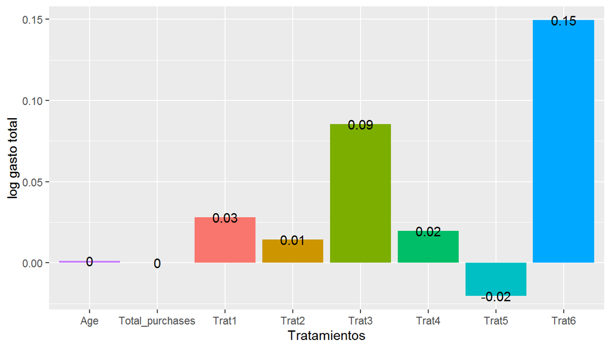

```r
eval13<-as.data.frame(eval13$logtotal_p)
eval13$nombre<-c("Trat1","Trat2","Trat3","Trat4","Trat5","Trat6","Age","Total_purchases")

ggplot2::ggplot(data=eval13,aes(x=nombre, y=estimate, fill=rownames(eval13)))+geom_bar(stat="identity")+guides(fill=FALSE)+labs(x="Tratamientos", y="log gasto total")+geom_text(aes(label=round(estimate,digits=2)))
```

```r
(eval13)
```

| term | estimate | std.error | statistic | p.value | nombre |
| --- | --- | --- | --- | --- | --- |
| factor(treat)1 | 2.818883e-02 | 6.427135e-02 | 0.4385909 | 6.609589e-01 | Trat1 |
| factor(treat)2 | 1.448732e-02 | 6.427130e-02 | 0.2254089 | 8.216617e-01 | Trat2 |
| factor(treat)3 | 8.533313e-02 | 6.427231e-02 | 1.3276811 | 1.842864e-01 | Trat3 |
| factor(treat)4 | 1.964473e-02 | 6.427728e-02 | 0.3056248 | 7.598910e-01 | Trat4 |
| factor(treat)5 | -2.031386e-02 | 6.427621e-02 | -0.3160402 | 7.519727e-01 | Trat5 |
| factor(treat)6 | 1.493953e-01 | 6.386301e-02 | 2.3393082 | 1.932137e-02 | Trat6 |
| age | 1.315510e-03 | 1.571394e-04 | 8.3716066 | 5.753072e-17 | Age |
| total_purchases | 8.795783e-06 | 3.044664e-06 | 2.8889171 | 3.866506e-03 | Total_purchases |

### 14 (4ptos). Describre que variables necesitas para hacer un análisis costo beneficio completo. Les doy algunas: Ticket promedio $100, Customer Lifetime value: $1,100. Con esto, que sistema de incentivos recomendarías? Porqué? Muestra el razonamiento detrás de tu recomendación

ara el analisis costo beneficio es importante destacar que se busca el mayor alcanze (utilidad) al menor uso de dinero o recursos. El alcance puede ser por beneficios directos como: ticket promedio, numero de nuevos usuarios y/o transaccionalidad. Asi, como tambien puede ser por beneficios indirectos: un incremento en el customer lifetime value, reduccion de incurrir en algun gasto.

Las variables que se recomiendan tomar en cuenta por lo tanto son:

- Gasto total promedio
- Beneficio total por tratamiento
- Beneficio total por usuario
- Costo total del tratamiento
- Costo total por usuario
- Razon costo-beneficio neto
- Ticket promedio
- Customer Lifetime value
- Transaccionalidad
- Nuevos usuarios
- Nuevos usuarios por edad

De acuerdo a los datos y tomando en cuenta el ticket promedio 100mxm y customer lifetimevalue 1100mxm, se elige el tratamiento 6, porque el costo es bajo (no es el mas bajo tampoco pero si con mayor impacto) y el valor agregado de un nuevo usuario es muy alto (en promedio).

### 15 (2ptos). Realiza la estimación de efectos heterogeneos para ambas variables usando `population`. Que encuentras? existe alguna subpoblación para la que los efectos difieran del promedio? Para cada efecto, muestra gráficas como lo hiciste en los ITTs

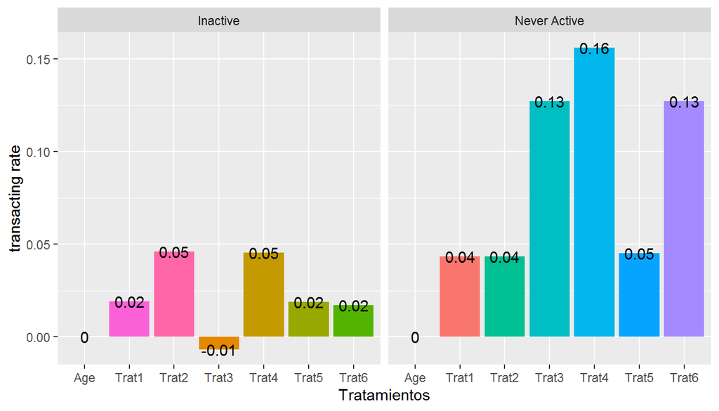

```r
# Efectos heterogéneos para transaccionalidad
#Retiramos la variable de control "total_purchases"

eval15<-impact_eval(data=universo_f,endogenous_vars="transacted",treatment = "treat",
                       heterogenous_vars = c("phone_verified","population","device_value"),
                       fixed_effect_vars = c("phone_verified","population","device_value"),
                       control_vars = c("age"))

eval15transpop<-eval15$transacted_population

eval15transpop$nombre<-c("Trat1","Trat2","Trat3","Trat4","Trat5","Trat6","Age","Trat1","Trat2","Trat3","Trat4","Trat5","Trat6","Age")
eval15_df<-as.data.frame(eval15transpop)


ggplot2::ggplot(data=eval15_df,aes(x=nombre, y=estimate, fill=rownames(eval15_df)))+geom_bar(stat="identity")+guides(fill=FALSE)+labs(x="Tratamientos", y="transacting rate")+geom_text(aes(label=round(estimate,digits=2)))+facet_wrap(~population)
```

```r
#para gasto total:
eval16<-impact_eval(data=universo_f,endogenous_vars="logtotal_p",treatment = "treat",
                       heterogenous_vars = c("phone_verified","population","device_value"),
                       fixed_effect_vars = c("phone_verified","population","device_value"),
                       control_vars = c("age"))
```

```
Error in chol.default(mat[ok, ok]) : 'a' debe tener dimension > 0
```

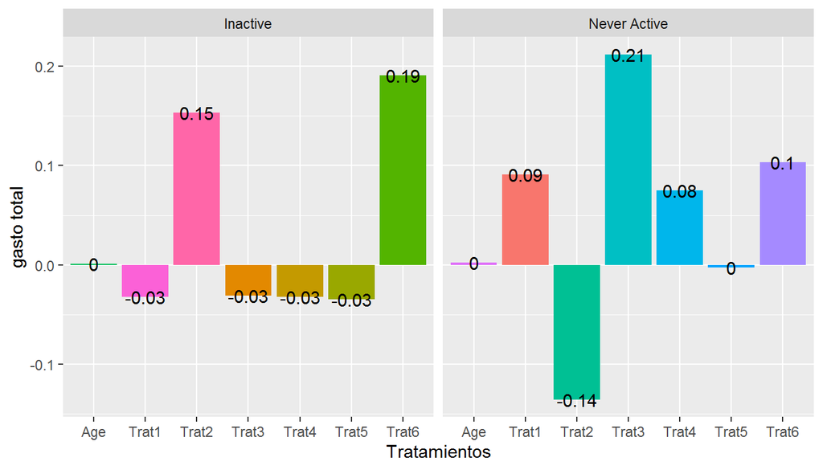

```r
eval16total_pur<-eval16$logtotal_p_population
eval16total_pur$nombre<-c("Trat1","Trat2","Trat3","Trat4","Trat5","Trat6","Age","Trat1","Trat2","Trat3","Trat4","Trat5","Trat6","Age")
eval16_df<-as.data.frame(eval16total_pur)

ggplot2::ggplot(data=eval16_df,aes(x=nombre, y=estimate, fill=rownames(eval16_df)))+geom_bar(stat="identity")+guides(fill=FALSE)+labs(x="Tratamientos", y="gasto total")+geom_text(aes(label=round(estimate,digits=2)))+facet_wrap(~population)
```

### 16 (2ptos). Repite el ejercicio para ``phone_verified`.

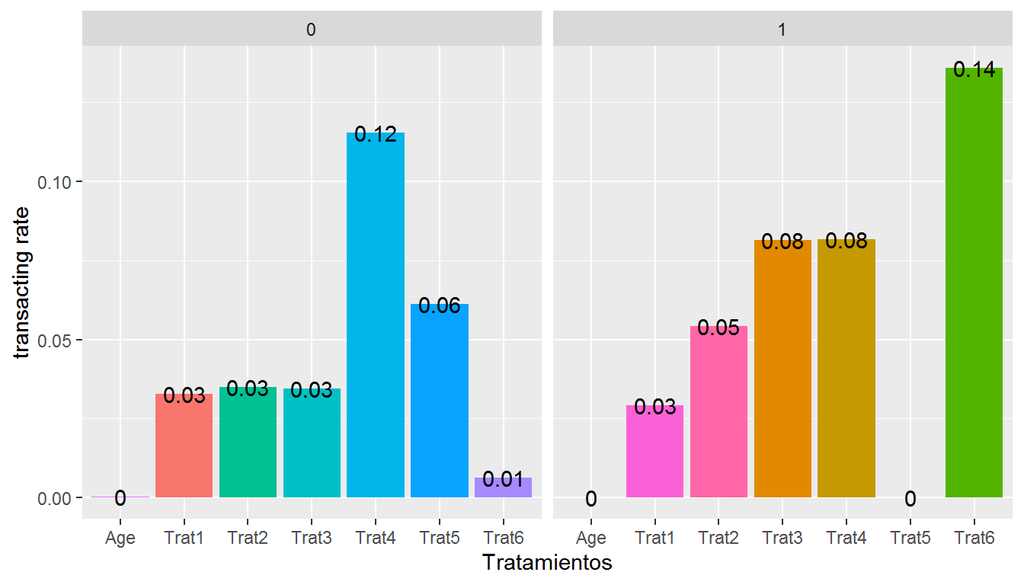

```r
# Efectos heterogéneos para transaccionalidad

universo_f$phone_verified<-factor(universo_f$phone_verified)
eval16t<-impact_eval(data=universo_f,endogenous_vars="transacted",treatment = "treat",
                       heterogenous_vars = c("phone_verified","population","device_value"),
                       fixed_effect_vars = c("phone_verified","population","device_value"),
                       control_vars = c("age"))

eval16t<-eval16t$transacted_phone_verified
eval16t$nombre<-c("Trat1","Trat2","Trat3","Trat4","Trat5","Trat6","Age","Trat1","Trat2","Trat3","Trat4","Trat5","Trat6","Age")
eval16t_df<-as.data.frame(eval16t)

ggplot2::ggplot(data=eval16t_df,aes(x=nombre, y=estimate, fill=rownames(eval16t_df)))+geom_bar(stat="identity")+guides(fill=FALSE)+labs(x="Tratamientos", y="transacting rate")+geom_text(aes(label=round(estimate,digits=2)))+facet_wrap(~phone_verified)
```

```r
# Para gasto total

eval18<-impact_eval(data=universo_f,endogenous_vars="logtotal_p",treatment = "treat",
                       heterogenous_vars = c("phone_verified","population","device_value"),
                       fixed_effect_vars = c("phone_verified","population","device_value"),
                       control_vars = c("age"))
```

```
Error in chol.default(mat[ok, ok]) : 'a' debe tener dimension > 0
```

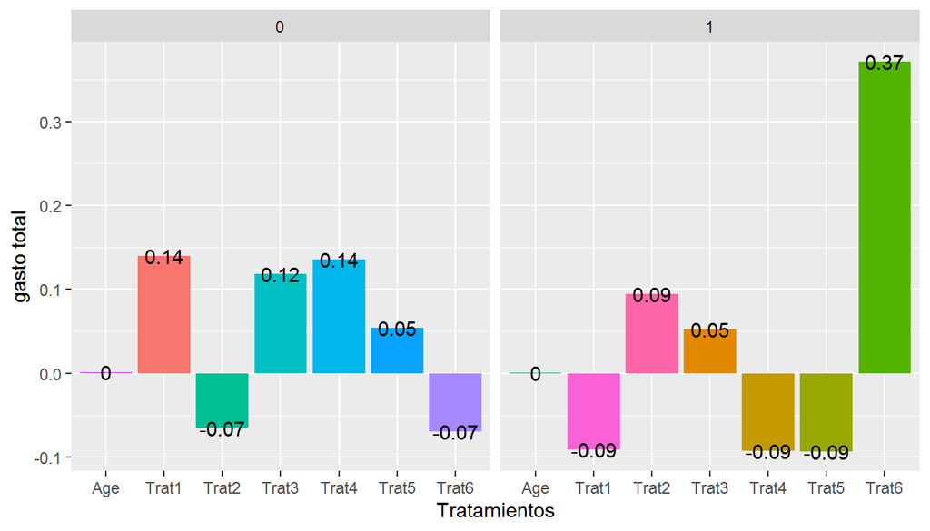

```r
eval18total_pur<-eval18$logtotal_p_phone_verified
eval18total_pur$nombre<-c("Trat1","Trat2","Trat3","Trat4","Trat5","Trat6","Age","Trat1","Trat2","Trat3","Trat4","Trat5","Trat6","Age")
eval18_df<-as.data.frame(eval18total_pur)

ggplot2::ggplot(data=eval18_df,aes(x=nombre, y=estimate, fill=rownames(eval18_df)))+geom_bar(stat="identity")+guides(fill=FALSE)+labs(x="Tratamientos", y="gasto total")+geom_text(aes(label=round(estimate,digits=2)))+facet_wrap(~phone_verified)
```

### 17. Presenta una propuesta de focalización con base en tus resultados generales y heterogeneos.

1. Con base en todo lo anteriormente presentado el mejor estimulo contemplando el panorama general (costo-beneficio, la respuesta de los usuarios y la heterogeneidad), el programa a seguir seria Ofrecer 4% de descuento en la siguiente compra por cada usuario que refieran a aquellos usuarios que hayan verificado su celular y estén inactivados y dar un 25% de descuento en la siguiente compra a aquellos usuarios que jamás han sido activos.
2. El valor agregado ha sido encontrar el impacto de los diversos tratamientos sobre el gasto, por tanto se propone crear un algoritmo con el objetivo de identificar a los usuarios potenciales para cada tratamiento. Esto puede ser mediante clustering para encontrar el perfil de usuarios que tuvieron respuesta positiva ante los incentivos. De esta manera, en lugar de aleatorizar se podria focalizar a un grupo y tener una campaña mas intensiva.